# Capstone

Cassidy

12/15/2020

Load tidyverse etc.

```r
library(tidyverse)
library(dplyr)
library(scales)
```

```r
library(ggplot2)
```

# How many entires are predicted to have glaucoma (glaucoma = 1) ? What is the max RNFL4.mean of those predicted to have glaucoma. Compare to mean of those predicted not to have glaucoma? Is the value of RNFL4.mean able to predict glaucoma ?

```r
data <- read_csv('glaucoma_data/ds_whole.csv') %>% #read csv file
 print()
```

```
## # A tibble: 499 x 9
##    RL    glaucoma   age ocular_pressure    MD   PSD   GHT cornea_thickness
##    <chr>    <dbl> <dbl>           <dbl> <dbl> <dbl> <dbl>            <dbl>
##  1 OD           0    62              17 -0.54  1.81     0              558
##  2 OS           0    62              17 -0.64  1.38     0              564
##  3 OD           0    66              12 -1.65  2.89     2              490
##  4 OS           0    66              12 -1.14  3.88     2              495
##  5 OD           1    53              24 -2.9   3.78     2              547
##  6 OS           1    53              24 -8.04 12.8      2              535
##  7 OD           1    53              24 -3.89  4.12     2              547
##  8 OS           1    53              24 -8.39 11.6      2              535
##  9 OD           1    53              24 -3.61  3.69     2              547
## 10 OS           1    53              24 -7.91 12.8      2              535
## # … with 489 more rows, and 1 more variable: RNFL4.mean <dbl>
```

```r
data_g1 <- data %>%   #filter for glaucoma =1
  filter(glaucoma==1)

data_g0 <- data %>%   #filter for glaucoma =0
  filter(glaucoma==0)

count(data_g1)#glaucoma
```

```
## # A tibble: 1 x 1
##       n
##   <int>
## 1   297
```

```r
count(data_g0)#no glaucoma
```

```
## # A tibble: 1 x 1
##       n
##   <int>
## 1   202
```

```r
print(max(data_g1["RNFL4.mean"])) #max RNFL4.mean of those with glaucoma
```

```
## [1] 109.6667
```

```r
print(min(data_g1["RNFL4.mean"])) #min RNFL4.mean of those with glaucoma
```

```
## [1] 16
```

```r
print(max(data_g0["RNFL4.mean"]))#max RNFL4.mean of those without glaucoma
```

```
## [1] 162
```

```r
print(min(data_g0["RNFL4.mean"]))#min RNFL4.mean of those without glaucoma
```

```
## [1] 58.66667
```

```r
print((max(data_g0["RNFL4.mean"])-(max(data_g1["RNFL4.mean"])))) #difference between max RNFL4.mean for those with vs without glaucoma.
```

```
## [1] 52.33333
```

```r
print((min(data_g0["RNFL4.mean"])-(min(data_g1["RNFL4.mean"])))) #difference between min RNFL4.mean for those with vs without glaucoma.
```

```
## [1] 42.66667
```

# How does the ratio between ocular_pressure and cornea thickness change with age.

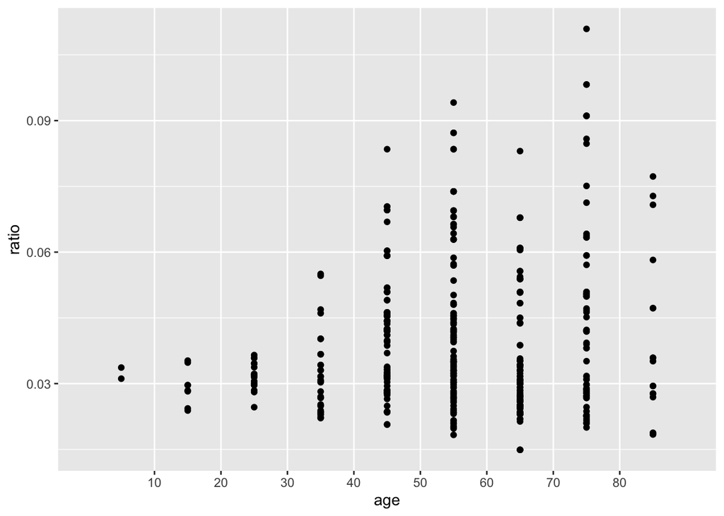

```r
q2 <- data %>%
  mutate(ratio = (ocular_pressure / cornea_thickness)) %>% #create new column
  select(ratio, age) %>% #pull out only these #lets just look at the new column compared to age
  ggplot(aes(x = age, y = ratio)) +
  geom_point() +
  scale_y_continuous()+
  scale_x_binned(n.breaks = 10) #bin into 10 age groups

q2 #print
```

## Answer

The graph shows that as age increases, so does the range of ratios observed. Ages 1-40 have smaller variation in this ratio. There also seems to be a slight increased ratio associated with increased age.

# REPRODUCIBILITY

Question 1 code will work for any column where an assigned value can be called on, in this case 0 or 1. Question 2 code is reproducible for all values that can be divided. The scaling may need to be changed for different datasets and questions.